# 07_GLM_Binomial_Model

Callum Weinberg

March 9, 2022

# Functions

```r
#Function for QQ Plot in GGPLOT
# Source: https://stackoverflow.com/questions/4357031/qqnorm-and-qqline-in-ggplot2
qqplot_residuals <- function (vec) # argument: vector of numbers
{
  # following four lines from base R's qqline()
  y <- quantile(vec[!is.na(vec)], c(0.25, 0.75))
  x <- qnorm(c(0.25, 0.75))
  slope <- diff(y)/diff(x)
  int <- y[1L] - slope * x[1L]
  d <- data.frame(resids = vec)
  ggplot(d, aes(sample = resids)) +
    stat_qq(color = "blue", alpha = .2) +
    geom_abline(slope = slope, intercept = int) +
    theme(plot.title = element_text(hjust = 0.5)) +
    theme_minimal()
}
```

# Load the Data

```r
## Load the Data from the 02 File
load(file="Intermediate_Data/03_model_data.Rdata")
```

# Create Training and Test sets:

```r
# Set Seed for Reproducibility
set.seed(42)
# training set 80% of original data
train = sample(nrow(model_data), .8*(nrow(model_data)))
x.train = model_data[train, ]
y.train = model_data[train, ]$renewable_percent_2017
# test set remaining 20% of original data
x.test = model_data[-train, ]
y.test = model_data[-train, ]$renewable_percent_2017
```

```r
library(glmnet)
library(bamlss)
library(cowplot)
library(ggplot2)
```

## Beta Regression Justification

When fitting a linear model for prediction (or interpretation), the "linear model" (often referred to as "ordinary linear regression") is often considered the simplest and first choice for a continuous response. However, such model is not alwyas appropriate. The linear model estimates the response directly as a linear combination of the $\mathbf{\beta}$ matrix and $\mathbf{X}$ matrices, with an error matrix as well. This is of the form:

$$\mathbf{Y} = \mathbf{X}\mathbf{\beta} + \mathbf{\epsilon}$$

where $\mathbf{Y}$ and $\mathbf{\epsilon}$ are $n\times 1$ matrix, $\mathbf{X}$ is a $n\times p$ matrix, and $\mathbf{\beta}$ is a $p\times 1$ matrix. The $\beta$ coefficients are fit using the data with least squares estimates, and the residuals can be analyzed for normality. Such a model clearly assumes additive error. Additionally, it is generally desirable for the errors to be normally distributed (and therefore this can be reffered to as a Gaussian model) for inference purposes, although it is not strictly necessary for estimating the coefficients.

Practically, issues with the additive error term become apparent when we consider what constraints we may want on $\mathbf{Y}$. For renewable energy percentages in 2017, we clearly want a model that predicts a percentage, i.e. values between 0 and 1. The simple linear model does not guarentee this: coefficients could be estimated for values less than 0 or greater than 1. Therefore it is appropriate classes of models from the more "general" set of "generalized linear models." The genearlized linear model allows for the $\mathbf{X}\mathbf{\beta}$ matrix (called the systematic component - this portion must be linear in the $\beta's$) to be related to the response via a link function, and incorporates the error into a "random" component.

The choice of generalized linear model (GLM) depends on what values the response can take on. Logistic regression (technically bernoulli regression) is a form of GLM that applies for binary responses, and uses the logit link function. In this problem, the response is continous. When applying linear models to proportions, it must be determined whether the underlying values are counts or an actual proportion. If they are counts, then binomial regression (bernoulli regression bu $n$ does not have to equal 1) or poisson regression are usually appropriate starting places. In this problem it is a bit unclear whether the values are actually counts divided by a total, or actually proportions. Generally energy is thought of as a continupus value, and not a discrete count. Therefore, the less common beta regression model is likely the most appropriate GLM here [CITE https://rcompanion.org/handbook/J_02.html].

Beta regression assumes the response variable follows a beta distribution.[^1] It also requires the response variable to be between 0 and 1, but not exactly 0 or 1. This is a problem for this dataset, as a few renewable percentages are 0 or 1. In order to make use of the model in spite of this, a small ammount of bias is introduced by setting values from the training set that are 0 equal to 0.000001 and values that are 1 equal to 0.999999. The model for a beta regression is as follows:

$$g(\mu_i) = \mathbf{X\beta}$$

where the mean percentage, $\mu$ accounts for the randomness and is modeled as a function of the systematic component, $\mathbf{X\beta}$. $g(.)$ is the link function. CITE[https://cran.r-project.org/web/packages/betareg/vignettes/betareg.pdf]. Different link functions are possible, but the default method for beta regression is typically the logit function, $g(\mu) = log(\frac{\mu}{1-\mu})$. This results in the model

$$log\bigg(\frac{\mu_i}{1-\mu_i}\bigg) = \mathbf{X\beta}$$

This looks similar logistic (bernoulli) regression. However the beta regression model incorporates a second parameter as well; the precision $\phi$ sometimes referred to as the dispersion $\phi^{-1}$. The precision can be constant or modeled. CITE[https://cran.r-project.org/web/packages/betareg/vignettes/betareg.pdf]. In the package used in this project it is fit using a logit link as well and is modeled to be approximately 1, see below.

Information of the package can be found here CITE[https://arxiv.org/pdf/1909.11784.pdf] and here http://www.bamlss.org/. stands for "Bayesian additive models for location, scale and shape." CITE[https://arxiv.org/pdf/1909.11784.pdf] The package appears very powerful and capable of bayesian generalized additive models. For the purposes of this report, only a generalized linear model is needed. Instead of maximum likelihood estimation to estimate the parameters, a bayesian approach is implemented, with prior distributions assigned to the $\beta's$.CITE[https://arxiv.org/pdf/1909.11784.pdf page 12] The package also automatically implements a lasso-type penalty, inducing regularization and setting some of the coefficients to 0, thus creating a sparse model. CITE[https://arxiv.org/pdf/1909.11784.pdf page 9].

Note that the package uses BIC (Bayesian Information Criterion) to select the optimal model. This is different than the other methods in this report, which rely on cross validation. To the best of the authors's knowledge, a simple ti implement cross-validation approach is not available for the package.

```r
## First, set the seed for reproducibly.
set.seed(42)
# Beta Regression Values must be strictly between 0 and 1
y.train = ifelse(y.train == 0,y.train + .000001,y.train)
y.train = ifelse(y.train == 1,y.train - .000001,y.train)
## Model formula.
## y.train instead of renewable_percent 2017
beat_regression_model = y.train ~ X2017_Population_World_Bank + X2017_Land_Area_km_2 + X2017_GDP_US_Dollars_World_Bank +
  CH4 + CO2 + GHG + NOx + energy_supply_petajoules + energy_intensity_2017 +
  mining_value_2017 + percent_land_agricultural_2013 + nitrogen_consumption + phosphate_consumption +
  potash_consumption + terrestrial_protected_areas + protected_areas_marine_terrestrial + forest_area_2015 + Basel_Convention +
  CITES + Convention_on_Biological_Diversity + Kyoto__Protocol + Montreal_Protocol + Paris_Agreement + Ramsar_Convention +
  Rotterdam_Convention + Stockholm_Convention + UN_Convention_on_the_Law_of_the_Sea + UN_Convention_to_Combat_Desertification +
  UN_Framework_Convention_on_Climate_Change + World__Heritage_Convention
  # + energy_supply_2017
## Estimate model.
## The data is input in matrix form
beta_model = bamlss(beat_regression_model, family = "beta",
                    data = cbind(y.train,x.train),
                    optimizer = lasso, criterion = "BIC",
                    n.iter = 12000, burnin = 2000, thin = 10)
```

[output not shown]

[output cut: 89 more lines]

[output not shown]

```r
## Summary of the model
summary(beta_model)
```

```
Call:
bamlss(formula = beat_regression_model, family = "beta", data = cbind(y.train,
    x.train), optimizer = lasso, criterion = "BIC", n.iter = 12000,
    burnin = 2000, thin = 10)
---
Family: beta
Link function: mu = logit, sigma2 = logit
*---
Formula mu:
---
y.train ~ X2017_Population_World_Bank + X2017_Land_Area_km_2 +
    X2017_GDP_US_Dollars_World_Bank + CH4 + CO2 + GHG + NOx +
    energy_supply_petajoules + energy_intensity_2017 + mining_value_2017 +
    percent_land_agricultural_2013 + nitrogen_consumption + phosphate_consumption +
    potash_consumption + terrestrial_protected_areas + protected_areas_marine_terrestrial +
    forest_area_2015 + Basel_Convention + CITES + Convention_on_Biological_Diversity +
    Kyoto__Protocol + Montreal_Protocol + Paris_Agreement + Ramsar_Convention +
    Rotterdam_Convention + Stockholm_Convention + UN_Convention_on_the_Law_of_the_Sea +
    UN_Convention_to_Combat_Desertification + UN_Framework_Convention_on_Climate_Change +
    World__Heritage_Convention
-
Parametric coefficients:
                                                Mean       2.5%        50%      97.5% parameters
(Intercept)                                2.097e+02 -4.617e+02  2.274e+02  8.147e+02    202.119
X2017_Population_World_Bank                2.127e-09 -4.316e-09  2.135e-09  8.920e-09      0.000
X2017_Land_Area_km_2                      -5.011e-07 -1.065e-06 -4.941e-07  3.042e-08      0.000
X2017_GDP_US_Dollars_World_Bank            3.163e-13 -4.506e-13  3.001e-13  1.166e-12      0.000
CH4                                        2.154e-06 -1.031e-05  2.066e-06  1.375e-05      0.000
CO2                                       -2.339e-07 -1.170e-05  1.020e-07  1.073e-05      0.000
GHG                                        7.586e-07 -8.661e-06  6.402e-07  1.074e-05      0.000
NOx                                        4.503e-04 -1.209e-03  3.928e-04  1.941e-03      0.000
energy_supply_petajoules                  -1.589e-04 -4.730e-04 -1.494e-04  1.688e-04      0.000
energy_intensity_2017                      2.509e-03 -4.946e-04  2.579e-03  5.399e-03      0.003
mining_value_2017                         -3.465e-02 -6.187e-02 -3.404e-02 -5.498e-03     -0.033
percent_land_agricultural_2013            -1.410e-02 -2.673e-02 -1.396e-02 -2.009e-03     -0.014
nitrogen_consumption                      -1.809e-03 -1.050e-02 -1.728e-03  6.279e-03     -0.002
phosphate_consumption                      5.372e-03 -1.981e-02  4.725e-03  3.017e-02      0.004
potash_consumption                        -1.814e-02 -3.603e-02 -1.775e-02 -4.670e-03     -0.017
terrestrial_protected_areas               -3.063e-03 -3.370e-02 -2.462e-03  3.226e-02     -0.002
protected_areas_marine_terrestrial         2.131e-02 -1.586e-02  2.090e-02  6.114e-02      0.019
```

[output cut: 28 more lines]

```
        Mean   2.5%    50% 97.5%
alpha 0.9721 0.7419 0.9998     1
---
Sampler summary:
-
DIC = -319.5839 logLik = 179.1992 pd = 38.8144
runtime = 31.744
---
Optimizer summary:
-
BIC = -236.7993 -> at lambda = 0.006135907 0.006135907
logLik = 199.1973 logPost = -51.2773 BIC = -236.7993 edf = 32
---
nobs = 156
---
```

The model is fit above. There are two important notes here. First, the energy_supply_2017 variable appears to cause some issue in fitting the model and is excluded. Secondly, since the bamlss function takes a bayesian approach, the $\beta's$ are modeled with posterior distributions. This involves sampling the posterior distribution using mote carlo estimation. The "n.iter", "burnin", and "thin" options relate to the sampling and the selected values were defaults suggested in a Vignette on the bamlss wepage.[https://bayesr.r-forge.r-project.org/articles/glm.html]

Before using the model for prediction, it is worth briefly evaluating whether it is an appropriate model with some diagnostic checking (the diagnostic checking is relatively limited for this report, as the main purpose of this report prediction). Residual plots are shown below:

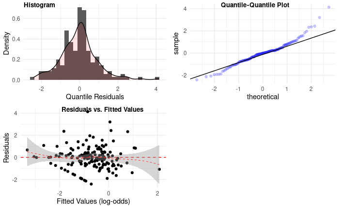

```r
# Model Residuals and Fitted Values
beta_model_residuals = residuals(beta_model, type = c("quantile"))
beta_model_fitted = fitted(beta_model)$mu[2]
beta_model_residuals_df = data.frame(res = beta_model_residuals,
                                     fit = beta_model_fitted)
colnames(beta_model_residuals_df) = c("res","fit")
# Histogram of Quantile Residuals
histogram_beta_residuals = ggplot(beta_model_residuals_df, aes(x = res)) +
  geom_histogram(aes(y = ..density..)) +
  geom_density(alpha = 0.1, fill = "red") +
  labs(x = "Quantile Residuals", y = "Density") +
  theme(text = element_text(size = 20),
    axis.text.y = element_text(angle=90, hjust=1, size = 10),
    axis.text.x = element_text(size = 10),
    plot.title = element_text(hjust = 0.5, size = 12),
    axis.title=element_text(size=10,face="bold")) +
  theme_minimal()
# QQ Plot of Quantile Residuals
qq_beta_residuals = qqplot_residuals(beta_model_residuals)
# Residual vs. Fitted Plot
resid_vs_fit_model = ggplot(beta_model_residuals_df,
                              aes(x = fit, y = res)) +
  geom_point() +
  geom_hline(yintercept = 0, linetype = 2, color = "red", size = .5) +
  geom_smooth(formula = "y~x", method = "loess",
              se=TRUE, linetype = 2, color = "red", size = .25) +
  labs(x="Fitted Values (log-odds)",y="Residuals") +
  theme(plot.title = element_text(hjust = 0.5)) +
  theme_minimal()
# Plot
plot_grid(histogram_beta_residuals,qq_beta_residuals, resid_vs_fit_model,
          ncol = 2, nrow = 2,
          labels = c("Histogram", "Quantile-Quantile Plot", "Residuals vs. Fitted Values"),
          label_size = 10,
          hjust = -.75)
```

Quantile residuals are provided by the package and are used here per the reccomendation from the bamlss website [CITE https://bayesr.r-forge.r-project.org/articles/glm.html]. The diagnostic plots overall suggest the beta regression model is an acceptable choice for the data, if not quite perfect. The histogram and the quantile-quantile plot (QQ Plot) both suggest the residuals are very roughly normally distributed. The histogram roughly looks like a normal distribution. The normal qunatiles and quantiles of the residuals roughly track, with some rightward skew. This suggests there are some outliers in the residuals on the right-hand side of the distribution (in the QQ Plot, the blue dots would track the black line exactly if the residuals were normally distributed). Finally, the residuals versus fitted plot shows the relationship between the residuals and the predicted values of the training data. Note the fitted values here are the log odds, and not in terms of percentages (as specified by the model). There should be now obvious relationship or heteroskedasticity. The plot suggests rough randomness in the relationship. Overall, the plots suggest that the model does not predict high renewable energy percentages particularly well, but the choice of a beta regression model seems somewhat justified.

Given the model is adequate, prediction is done using the test data. Note that predicted values are available for the posterior mean and variance parameters, but only the predicted value is analyzed here (not the uncertainty around said prediction).

```r
# Use the predict function and the test data
beta.pred = predict(beta_model, newdata = x.test, type = "parameter")$mu
# Calculate Mean Squared Error and Mean Absolute Error
beta_rmse = sqrt(mean((y.test-beta.pred)^2))
beta_abs_e = mean(abs(y.test-beta.pred))
# Calculate Bias
beta.fit = predict(beta_model, newdata = x.train, type = "parameter")$mu
beta_bias = mean(beta.fit - y.train)
```

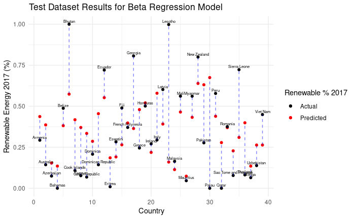

```r
# Create Data Frame with Countries, Predicted Values
# And Actual Values
beta_predict_graph_data = data.frame(observation = c(1:39),
           prediction = beta.pred,
           actual = y.test,
           Country = x.test$Country_Final)
# Specifiy minimum and maxium in each case for plotting
# the line between points
beta_predict_graph_data = beta_predict_graph_data %>%
  mutate(min_value_col = pmin(prediction,actual)) %>%
  mutate(max_value_col = pmax(prediction,actual)) %>%
  mutate(Abs_Diff = abs(actual-prediction))
# Plot the Predictions vs. Actual with difference lines and labels
ggplot(data = beta_predict_graph_data, aes(x = observation, label = Country)) +
  geom_point(aes(y = prediction, color = 'Predicted')) +
  geom_point(aes(y = actual, color='Actual')) +
  geom_linerange(aes(ymin = min_value_col, ymax = max_value_col),
                col = "blue", linetype = "dashed", alpha = .5) +
  geom_text(aes(y = actual), size = 2, vjust = -.5) +
  labs(title = "Test Dataset Results for Beta Regression Model",
       x="Country",y="Renewable Energy 2017 (%)") +
  scale_color_manual(name='Renewable % 2017',
                     breaks=c('Actual', 'Predicted'),
                     values=c('Actual'='black', 'Predicted'='red')) +
  theme(legend.title=element_text(size=20), legend.text=element_text(size=14)) +
  theme_minimal()
```

The above graph shows the difference between the predicted values and the actual values for renewable energy percentage in 2017. Generally, the largest source of error appears to come from countries that have actual renewable percentages close to or greater than .7.

```r
# Create Dataframe with Absolute Difference
# Arrange to be in Order
beta_predict_analysis_1 = beta_predict_graph_data %>%
  dplyr::select(-c(min_value_col,max_value_col)) %>%
  arrange(-Abs_Diff)
# Print out the Results
kable(rbind(head(beta_predict_analysis_1,5),
            tail(beta_predict_analysis_1,5)))
```

```
|   | observation| prediction| actual|Country          |  Abs_Diff|
|:--|-----------:|----------:|------:|:----------------|---------:|
|1  |          23|  0.1595657| 0.9980|Lesotho          | 0.8384343|
|2  |          30|  0.6745609| 0.0000|Palau            | 0.6745609|
|3  |          17|  0.3640839| 0.8063|Georgia          | 0.4422161|
|4  |           6|  0.5736927| 0.9999|Bhutan           | 0.4262073|
|5  |          35|  0.3096925| 0.7228|Sierra Leone     | 0.4131075|
|35 |          24|  0.1136313| 0.1636|Malaysia         | 0.0499687|
|36 |          26|  0.0734624| 0.0460|Mauritius        | 0.0274624|
|37 |          16|  0.3977580| 0.3707|French Polynesia | 0.0270580|
|38 |          19|  0.5203008| 0.5011|Honduras         | 0.0192008|
|39 |          33|  0.3694991| 0.3750|Romania          | 0.0055009|
```

```r
set.seed(43)
g = runif(1000000,0,1)
h = runif(1000000,0,1)
mean(abs(g-h))
```

```
[1] 0.3336515
```

[^1]: the probability density function is $f(y;\mu,\phi) = \frac{\Gamma(\phi)}{\Gamma(\mu\phi)\gamma((1-\mu)\phi)}y^{\mu\phi-1}(1-y)^{(1-\mu)\phi-1}$
[^2]: Writing a new package that does this was considered outside the scope of this project